# PG2 - Segunda Entrega 2

### **5.3 MODELO DE DISTRIBUCIÓN NORMAL- INGRESO ECONÓMICO DEL USUARIO**

Ahora analizaremos la variable en base a la distribución normal, para ello, en R utilizaremos la función pnorm(x, media, desv_est).

- Estimaremos la probabilidad de que al escoger un usuario al azar que ha dado click en el anuncio falso el ingreso económico anual de dicho usuario sea mayor a $40000.

$X∼N(μ,σ)$ y determinamos $P(X>=40)$ De los descriptores numéricos analizados previamente obtenemos: $μ=49262$ $σ=13500.77$

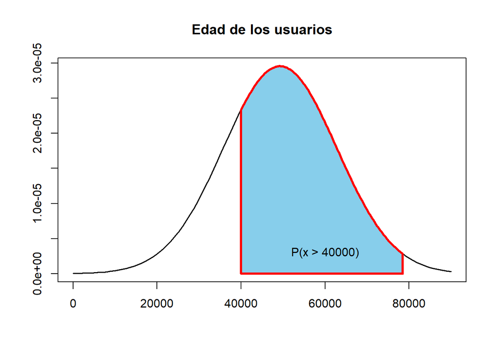

```r
#DISTRIBUCIÓN DE LA PROBABILIDAD:
μ <- mean(Ingreso_economicosiclick$`Ingreso económico del usuario`)
σ <- sd(Ingreso_economicosiclick$`Ingreso económico del usuario`)

x2 <- c(40000, seq(40000,78521,length=100),78521)
y2 <- c(0, dnorm(seq(40000,78521,length=100), mean = μ, sd = σ), 0)

curve(dnorm(x, mean = μ, sd = σ), from=0, to=90000, ylab="",xlab = "",lwd = 1.75, main="Edad de los usuarios")
polygon(x2, y2, col = "sky blue", border = "red", lwd = 3)
text(x = 60000, y = 0.000003, 'P(x > 40000)' ,cex = 1)
```

```r
round(pnorm(40000,mean = μ,sd = σ,lower.tail = F),2)
```

```
## [1] 0.75
```

Podemos observar que la probabilidad de que los usuarios que ingresaron al anuncio tengan un ingreso anual mayor a $40000 es de 0.75.

- Estimaremos la probabilidad de que al escoger un usuario al azar que ha dado click en el anuncio falso el ingreso económico anual de dicho usuario sea menor a $30000

[figure not shown]

```r
#DISTRIBUCIÓN DE LA PROBABILIDAD:
μ <- mean(Ingreso_economicosiclick$`Ingreso económico del usuario`)
σ <- sd(Ingreso_economicosiclick$`Ingreso económico del usuario`)

x2 <- c(20593, seq(20593,30000,length=100),30000)
y2 <- c(0, dnorm(seq(20593,30000,length=100), mean = μ, sd = σ), 0)

curve(dnorm(x, mean = μ, sd = σ), from=0, to=90000, ylab="",xlab = "",lwd = 1.75, main="Edad de los usuarios")
polygon(x2, y2, col = "sky blue", border = "red", lwd = 3)
text(x = 11000, y = 0.000004, 'P(x > 30000)' ,cex = 1)
```

```r
round(pnorm(30000,mean = μ,sd = σ),2)
```

```
## [1] 0.08
```

Podemos observar que la probabilidad de que los usuarios que ingresaron al anuncio tengan un ingreso anual menor a $30000 es de 0.08.

- Estimaremos la probabilidad de que al escoger un usuario al azar que ha dado click en el anuncio falso el ingreso económico anual de dicho usuario este entre 30000 y 40000 $.

$X∼N(μ,σ)$ y determinamos $P(X>=[30000:40000])$ De los descriptores numéricos analizados previamente obtenemos: $μ=49262$ $σ=13500.77$

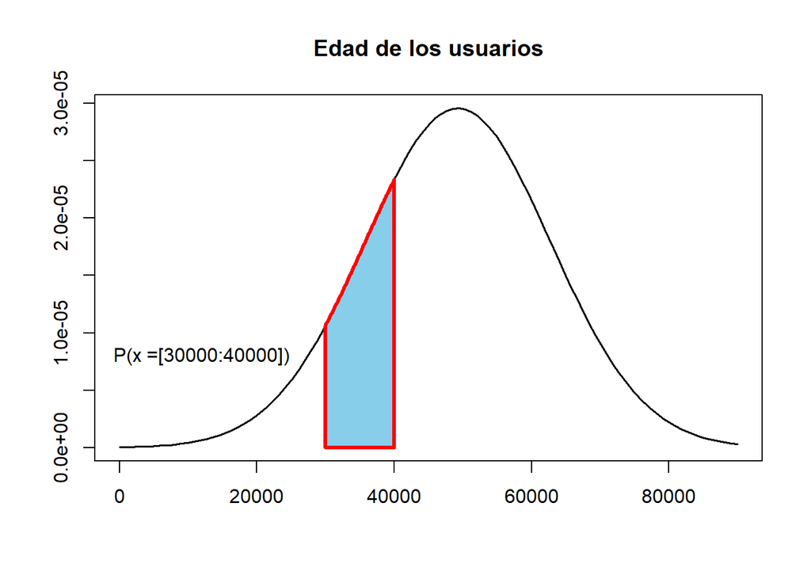

```r
#DISTRIBUCIÓN DE LA PROBABILIDAD:
μ <- mean(Ingreso_economicosiclick$`Ingreso económico del usuario`)
σ <- sd(Ingreso_economicosiclick$`Ingreso económico del usuario`)

x2 <- c(30000, seq(30000,40000,length=100),40000)
y2 <- c(0, dnorm(seq(30000,40000,length=100), mean = μ, sd = σ), 0)

curve(dnorm(x, mean = μ, sd = σ), from=0, to=90000, ylab="",xlab = "",lwd = 1.75, main="Edad de los usuarios")
polygon(x2, y2, col = "sky blue", border = "red", lwd = 3)
text(x = 12000, y = 0.000008, 'P(x =[30000:40000])' ,cex = 1)
```

```r
round(pnorm(40000,mean = μ,sd = σ)-(pnorm(30000,mean = μ,sd = σ)),2)
```

```
## [1] 0.17
```

Podemos observar que la probabilidad de que los usuarios que ingresaron al anuncio tengan un ingreso anual entre 30000 y 40000$ es de 0.17.

### **5.4 MODELO DE DISTRIBUCIÓN POISSON - TIEMPO DIARIO EN INTERNET**

Para este problema elegimos la variable tiempo diario en Internet(minutos) que pasan los usuarios que dieron click en el anuncio.

Con table observamos el tiempo diario en Internet(minutos) que pasan los usuarios que dieron click en el anuncio.

```r
table(Si_Click$`Tiempo diario en internet`)
```

```
##
## 105 106 107 108 109 110 111 112 113 114 115 116 117 118 119 120 121 122 123 124
##   5   6   3  10   8   3   6   6   3   6   6   8   5   7   9  11   9   6   7  12
## 125 126 127 128 129 130 131 132 133 134 135 136 137 138 139 140 141 142 143 144
##  13   7   8   9  10   4   4  11   8   6   9   7   9   5  10   3   9   7   5   4
## 145 146 147 148 149 150 151 152 153 154 155 156 157 158 159 160 161 162 163 164
##   7   6   1   5   4   5  11  10   4   6   5   4   4   4   6   6   6   8   4   1
## 165 166 167 168 169 170 171 172 173 174 175 177 178 179 180 181 182 183 184 185
##   2   4   6   7   5   2   2   4   6   1   3   6   1   3   1   1   2   1   1   2
## 187 189 190 191 193 194 195 196 197 198 199 200 201 202 203 204 207 208 209 211
##   1   1   2   2   1   2   2   4   2   2   1   2   1   1   1   2   1   1   1   1
## 213 214 216 220 222 225 229 232 236 240 249 250 253 255 256 259 270
##   1   1   1   2   1   1   1   1   1   1   1   1   1   1   1   1   1
```

**Establecemos un caso:**

- Se sabe que 11 usuarios que dieron click en el anuncio pasan en promedio 2 horas diarias(120minutos)en el ciberespacio estos siguen una distribución Poisson. ¿Cuál es la probabilidad de que 30 usuarios lleguen a pasar 4 horas(240 minutos en el espacio) al día en Internet?

```r
Tiempo125<-filter(Si_Click,`Tiempo diario en internet`==120)
nrow(Tiempo125)
```

```
## [1] 11
```

```r
mean(Tiempo125$`Tiempo diario en internet`)/60
```

```
## [1] 2
```

- “k” = 30
- “λ”: 11 x 4 = 44 $Poisson(k,λ)$

```r
dpois(30,44)
```

```
## [1] 0.005901508
```

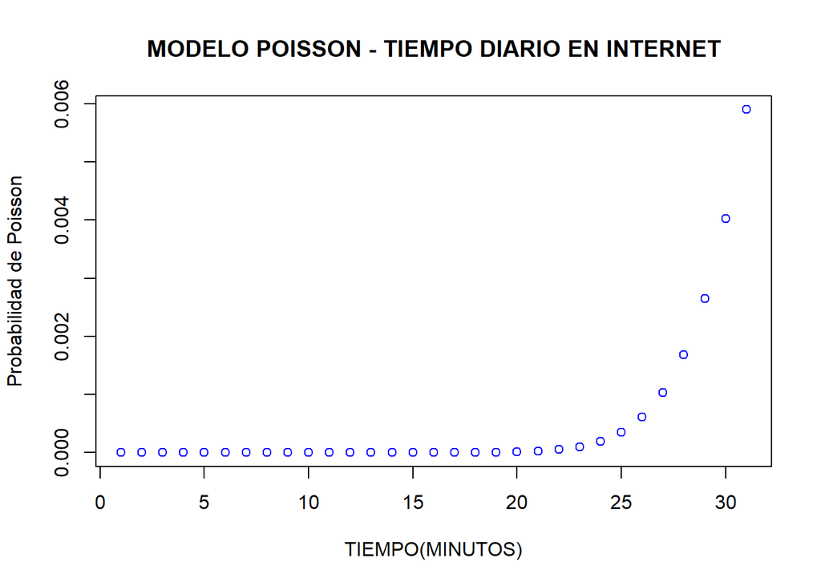

```r
plot(dpois(0:30,44),col = "blue",xlab = "TIEMPO(MINUTOS)",ylab = "Probabilidad de Poisson" ,main = "MODELO POISSON - TIEMPO DIARIO EN INTERNET")
```

La probabilidad de que 30 usuarios lleguen a pasar 4 horas al día en el internet es de 0.0059 => 0.59%.

**Caso 2** - Se sabe que 35 usuarios que dieron click en el anuncio falso pasan en promedio 1.792381 horas al día en el Internet, este sigue una distribución de Poisson. ¿Cuál es la probabilidad de que hasta 50 usuarios lleguen a pasar 6 horas al día en internet?

```r
Tiempode110<-filter(Si_Click,`Tiempo diario en internet`<=110)
nrow(Tiempode110)
```

```
## [1] 35
```

```r
mean(Tiempode110$`Tiempo diario en internet`)/60
```

```
## [1] 1.792381
```

- “k” = 50
- “λ”: 35 x 1.792381= 62.733335 $Poisson(k,λ)$

```r
round(ppois(50,62.733335),3)
```

```
## [1] 0.057
```

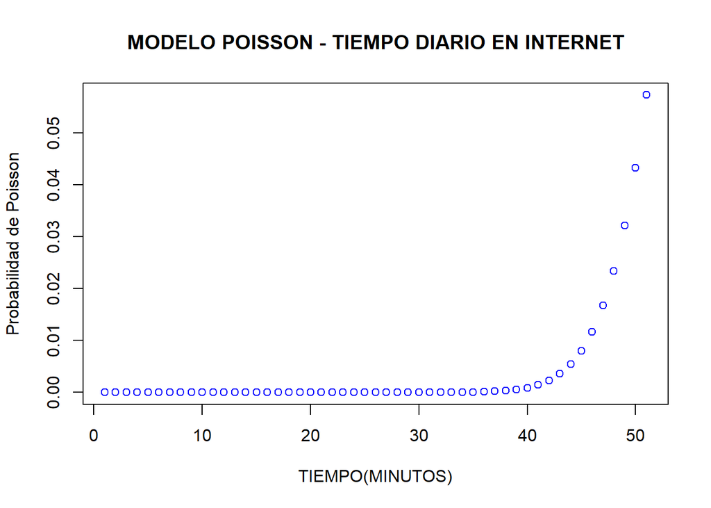

```r
plot(ppois(0:50,62.733335),col = "blue",xlab = "TIEMPO(MINUTOS)",ylab = "Probabilidad de Poisson" ,main = "MODELO POISSON - TIEMPO DIARIO EN INTERNET")
```

La probabilidad de que hasta 50 usuarios lleguen a pasar 6 horas al día en el internet es de 0.057 => 5.7%.

# **6.CONCLUSIONES** .

Tras el desarrollo del proyecto se ha conseguido recaudar diversos aprendizajes, los cuales nos han resultado de mucha ayuda para poder consolidar nuestro estudio acerca de la vulnerabilidad de este peligro cibernético a los usuarios durante su permanencia en los sitios webs. Asimismo, se ha logrado identificar las siguientes conclusiones:

- En cuanto a las relaciones, principalmente se tuvo como objetivo enfocarse en analizar a aquella población cibernauta que sí había dado click a estos anuncios falsos. Por lo que, se determinó una mayor predominancia del sexo femenino, cuya tendencia de moda en la edad resultaba siendo entre 40 a 45 años. Asimismo, se veía una influencia en cuanto al tiempo diario en internet y al tiempo de permanencia en el sitio web en el que permanecía el usuario.
- Adicionalmente, pudimos lograr identificar los análisis probabilísticos de las variables proporcionadas por la base de datos. Donde nuestro propósito consistía en buscar el modelo adecuado al comportamiento de cada variable, llegando a obtener así para la Edad de los usuarios, Sexo de los usuarios, Ingreso económico del área de los usuarios y el Tiempo diario en internet, planteandolos estos a un Modelo Normal, Binomial, Normal y Distribución Poisson, respectivamente.

# **7.BIBLIOGRAFÍA** .

- [1] Rodriguez, F. (s.f.). NUEVOS DELITOS INFORMÁTICOS: PHISING, PHARMING, HACKING Y CRACKING. Recuperado el 20 de noviembre del 2022. https://web.icam.es/bucket/Faustino%20Gud%C3%ADn%20-%20Nuevos%20delitos%20inform%C3%A1ticos.pdf
- [2] Santello, G. (s.f.). Advertisement - Click on Ad dataset. Recuperado el 5 de noviembre del 2022. https://www.kaggle.com/datasets/gabrielsantello/advertisement-click-on-ad?datasetId=2311024

# **INTEGRANTES DEL GRUPO**.

| **NOMBRE Y APELLIDOS** | **CÓDIGO** | **CARRERA** | **PORCENTAJE** |
| --- | --- | --- | --- |
| Gonzales Leyva, Saul Edgar | **202120241** | Ingeniería ambiental | **100%** |
| Jayo Gastelú, Diana | **202120305** | Ingeniería ambiental | **100%** |
| Quezada Murillo, Lina Mery | **202010510** | Ingeniería química | **100%** |
| Villanueva Perea, Diego José | **201810707** | Ciencias de la computación | **100%** |
| Castrejon Jimenez, Rosa Milagros | **202120141** | Ingeniería industrial | **100%** |